# IBS Microbiota analysis

Julien Tap

22 April, 2016

### Introduction

Here is a report of analysis regarding IBS microbiota dataset.

This report was made to be reproducible. It is made using R and report was automatically generated using knitr. All source code will be packaged and then available on my **github** space for any people who wanted to reproduce the analysis and figures. Sequences reads denoizing, quality checking, OTU clustering was made using the [LOTUS](http://psbweb05.psb.ugent.be/lotus/index.html) pipeline at 97% level of similarity.

### Methods summary

We proposed here classical numerical ecology (alpha and beta diversity) according health status. Unsupervised analysis helped to stratify microbiota samples into enterotypes. Dependance between health status and enterotypes was tested. Univariate testing was done at OTUs levels according severity and subtypes to check/quantify whether there was a signal according health group. Multivariates analysis was done to check global pattern between stool and biopsies. Machine learning approaches was used here not to find a diagnostic tools but to reduce the complexity of the dataset to reach the most interesting OTU (then called IBS OTUs signature). The microbial IBS dignature was then challenged aga../inst clinical metadata.

In order to achieve this, we used the [BiotypeR](https://github.com/tapj/biotyper) available on **github** and various others packages allowing plotting, parsing, parallelization and machine learning analysis.

### Study design and clinical characteristics in IBS patients and healthy subjects.

Here is the global design of the study. This included V4 and V5 samples.

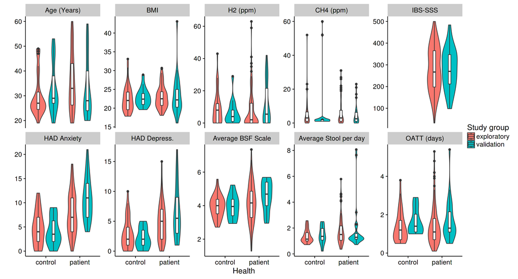

Study design

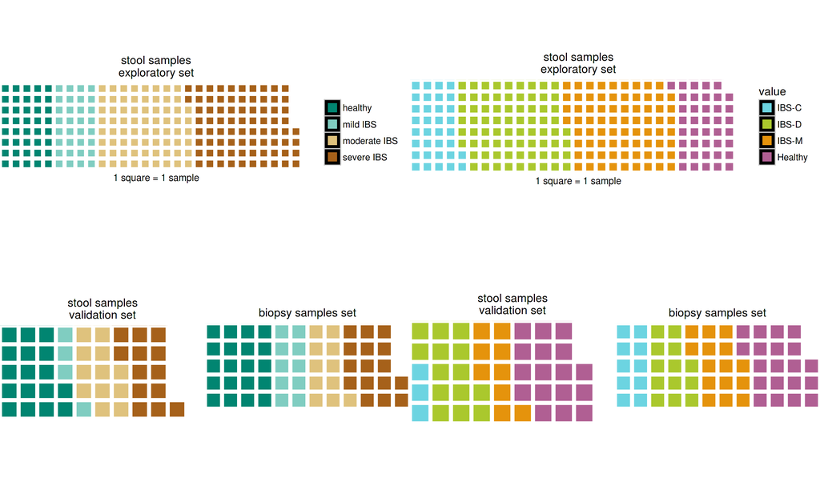

Study design

**Figure 1: Number of sample per dataset** This chart represent the number of samples as function of dataset and health status (Severity group and subtypes). each square represented one sample in this study.

> TO DO: a table with minimal clinical parameters for each set.

### Stool and biopsy microbial ecology of IBS patient and healthy control

Here we propose the following analysis on stool and biopsy between healthy and IBS patients stratified by severity and subtypes:

- Microbial OTUs richness comparison (alpha diversity)
- Microbial distance analysis within group (beta diversity within)
- Microbial distance analysis between IBS and Healthy (beta diversity between)

Additionally, we added those following analysis:

- Unsupervised enterotypes analysis
- Covariation analysis between paired stool/biopsy

> TO DO: ade4::apqe for each stratification, Quadratic Entropy

#### Microbial OTUs richness comparison

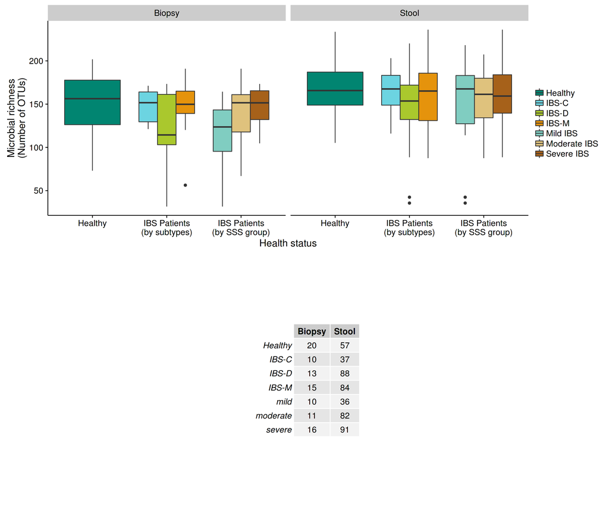

Stool and biopsy microbial richness

**Figure 2: Stool and biopsy microbial richness as function of health status** OTU microbiota richness evaluated at the same sequencing depth.

#### Microbial distance within and between group

The JSD entropy based metric was used to do pairwise comparisons between each sample.

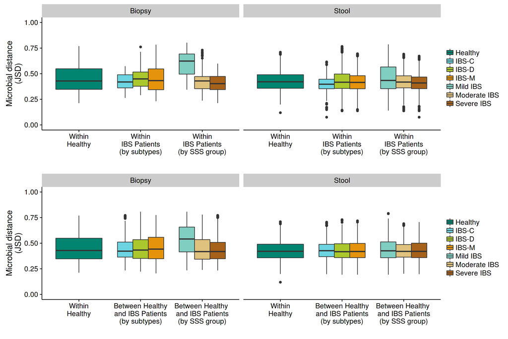

Within and Between analysis

**Figure 3: Stool and biopsy microbial distance as function of health status** Microbial distances between samples were evaluated using JSD metric.

Within beta-diversity was different only for mild IBS patient in biopsy. Compared to healthy, no difference was observed.

#### Enterotypes stratification

Using the Dirichlet multinomial distribution, we tried to stratify the stool microbiota. Baysian inference helped to determined the optimal number of Dirichlet component which correspond to the number of microbiota type in the dataset.

```
## class: DMN
## k: 3
## samples x taxa: 278 x 62
## Laplace: 52698.99 BIC: 53075.19 AIC: 52734.19
```

BIC and Laplace estimators indicated that 3 microbiota types were detected. For downstream analysis, we explored only 3 microbiota types.

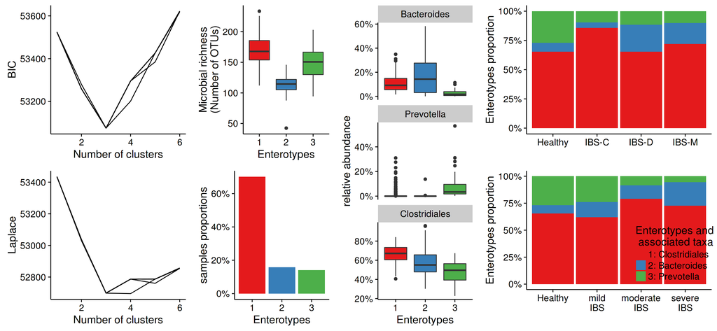

Enterotypes distribution according Health status)

**Figure 4: Enterotypes stratitification and distribution according Health status**. (Top panel) BIC and Laplace estimator indocated that 3 type of microbiota are deteceted in the dataset. (Bottom panel) Microbial enterotypes were independant from IBS severity and subtypes. There is a trend with an enrichment of Bacteroides-enriched enterotypes and less prevotella-enriched enterotypes.

No difference between group was observed regarding enterotypes distribution.

#### Co-inertia analysis between stool and biopsies

> DONE: add an additional figures with stool/biopsy differences at phylum levels abundances. TO DO: put a title on pdf file

### Discriminating analysis of between IBS and healthy at OTU levels

We have made univariate test (unparametric wilcoxcon test) to compare IBS and healthy stool microbiota at OTU levels. In total, more than 2,900 OTUS was deteceted. The made problem with such analysis on this king of dataset was to find significant OTU just by chance. This analysis was useful to determine if there was a intersting signal from severity and IBS subtypes.

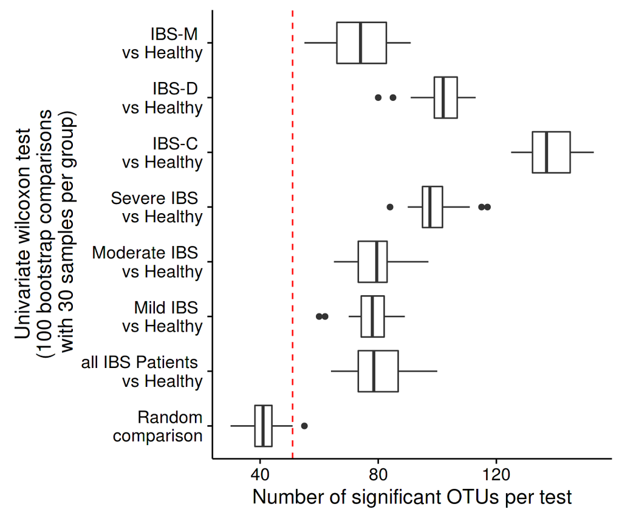

TRUE

### Stable and robust OTU based IBS signature using machine learning

Univariate test showed IBS severe and IBS-C microbiota might have some difference compared to Healthy microbiota. However, ramdom comparisons showed also that OTU could be significant just be chance. To avoid such caveat due to sampling effect and/or heterogeneity of our cohort, machine learning using LASSO model was used to select most robust OTU.

Custom script allowing machine learning based on LASSO regression was used here. 10 cross-validation and 10 bootstrap were realized to established 100 classification models. Cross-validation permitted to avoid statistical over-fitting and boostrapping allowed to homogenize data. Models were evaluated with AUROC analysis.

So, here are conditions which has been tested:

- Severe IBS vs rest at V4/V5
- IBS-C vs rest at V4/V5

All conditions was then analyzed with AUROC analysis…

…and was validated on biopsies set and the validation set.

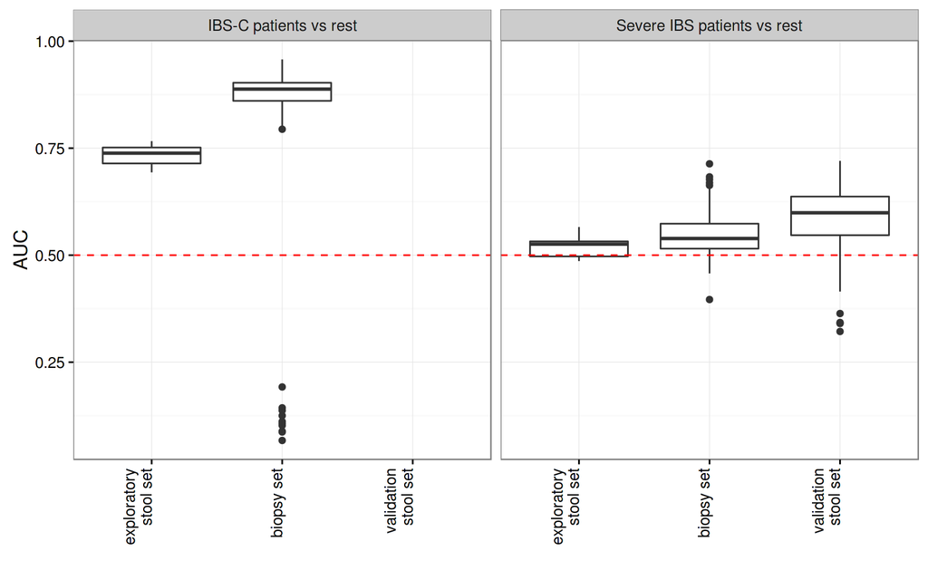

Model AUC performance

OTUs complexity reduction by machine learning allowing modelisation of IBS severity and IBS-C.

- For IBS severe: Validation on biopsies and external stool cohort (2nd batch)
- For IBC: not enough patients in IBSc in the 2nd batch.

Around ~90 OTUs (among ~2,900) was useful to model IBS severity.

### Microbial OTUs based IBS severe signature associations with clinical parameters

A PCA analysis using the 100 extracted OTUs and a multivariate analysis (Hill Smith based analysis) with mixed quantitatives and qualitatives clinical metadata were performed. Both analysis (OTU based PCA and the Hill/Smith) were then combined using a co-inertia analysis to check associations between discrimatives OTUs and clinical parameters.

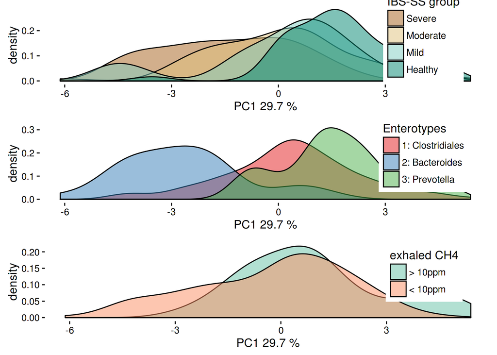

TRUE

[output not shown]

```
## [1] 18
```

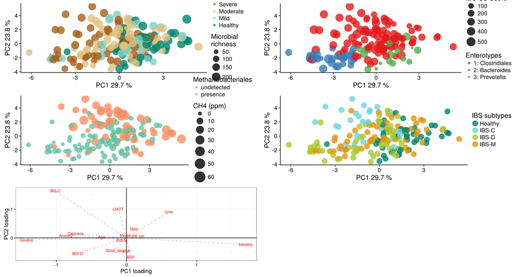

IBS signature and metadata

**Figure 8: Clinical and microbial metadata associations with IBS severe OTUs based signature.** Component detected from co-inertia analysis between OTU IBS severe signature and clinical metadata allowed to showed that severity gradient, microbial richness, enterotype stratification, CH4 exhaled, metanogens precence, lactulose challenge clusters and anxiety/depression were all linked with selected OTUs. H2 exhaled was not linked.

Combining clinical metadata and discriminative OTUs modelled for IBS severity allowed us to find significant associations between microbial richness, enterotypes, CH4 exhaled, presence of metanogens, HAD anxiety/depression and IBS severity. No associations were found with Age, BMI and H2 exhaled.

### Key messages and next steps

KEY MESSAGES

DONE STEPS (for the IBS severity 16S article):

- Figures polishing (notably combing figure into multi panel figures) = DONE
- OTUs IBS signature descriptions = DONE
- other clinical metadata comparisons = DONE
- alpha-diversity from enterotyping for sup info. = DONE